# Impacto del COVID-19 y la pobreza energética en las elecciones 2021

Gabriela Vargas Donato

2026-05-14

1. Introducción

Este informe analiza los determinantes del voto en la segunda vuelta electoral de 2021 en Perú a nivel provincial. El objetivo es identificar si el impacto de la pandemia del COVID-19 y las condiciones de vulnerabilidad estructural (pobreza energética) influyeron en la ventaja electoral de Pedro Castillo frente a Keiko Fujimori.

2. Preparación de los datos

Para este análisis, hemos fusionado (merge) tres fuentes de datos:

- Elecciones 2021: Tasa de votos Castillo/Keiko por provincia.
- Salud pública: Tasa de mortalidad COVID-19 por cada 100,000 habitantes en 2020.
- Censo 2017: Tipos de energía en el hogar como proxy de pobreza.

```r
# Cargamos bases procesadas
elecciones <- read_csv("Tasa_Provincial_2daVuelta_2021.csv")
covid <- read_csv("Tasa_Covid_2020_Provincial.csv")
energia <- read_csv("Base_Datos_Energia.csv") %>%
  rename(PROVINCIA = Provincia) %>%
  mutate(PROVINCIA = str_to_upper(str_trim(PROVINCIA)))

# Procesamiento de energía (tasas y cluster)
energia_pct <- energia %>%
  mutate(
    Pct_Gas = Gas_GLP / Total_Viviendas,
    Pct_Lena = Lena / Total_Viviendas,
    Pct_Bosta = Bosta_Estiercol / Total_Viviendas,
    Pct_Elec = Elec_Cocina / Total_Viviendas
  ) %>%
  select(PROVINCIA, Pct_Gas, Pct_Lena, Pct_Bosta, Pct_Elec) %>%
  drop_na()

set.seed(123)
mis_clusters <- kmeans(scale(energia_pct[,-1]), centers = 2)
energia_pct$Grupo_Pobreza <- as.factor(mis_clusters$cluster)

# Merge
base_analisis <- energia_pct %>%
  inner_join(elecciones, by = "PROVINCIA") %>%
  inner_join(covid, by = "PROVINCIA")
```

3. Análisis Cluster (Proxy de pobreza energética)

Se utilizó la técnica de Clustering (k-means) para agrupar las provincias según el tipo de energía que utilizan para cocinar.

Grupo 1: Provincias con mayor acceso a Gas GLP y Electricidad.

Grupo 2: Provincias con mayor uso de Leña y Bosta (Alta pobreza energética).

4. Análisis Bivariado

Exploramos la relación entre la mortalidad por COVID-19 y la preferencia electoral.

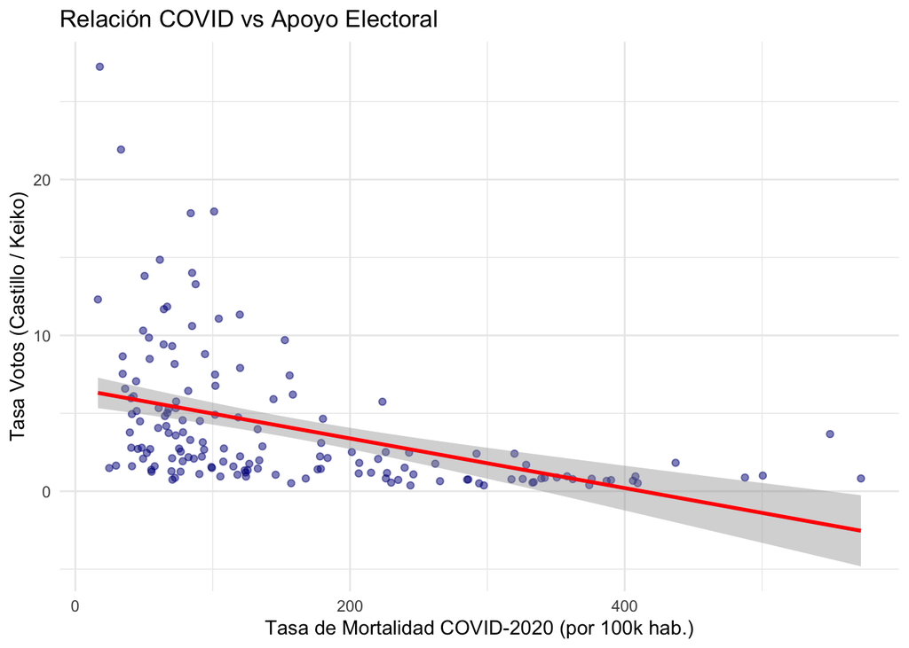

```r
ggplot(base_analisis, aes(x = Tasa_Covid_100k, y = Tasa_Castillo_Keiko)) +
  geom_point(alpha = 0.5, color = "darkblue") +
  geom_smooth(method = "lm", color = "red") +
  theme_minimal() +
  labs(title = "Relación COVID vs Apoyo Electoral",
       x = "Tasa de Mortalidad COVID-2020 (por 100k hab.)",
       y = "Tasa Votos (Castillo / Keiko)")
```

5. Modelo de Regresión Lineal Múltiple

Evaluamos el impacto conjunto de la pandemia y la pobreza energética en el voto.

```r
modelo_final <- lm(Tasa_Castillo_Keiko ~ Tasa_Covid_100k + Grupo_Pobreza, data = base_analisis)

stargazer(modelo_final, type = "html",
          title = "Determinantes del Voto en 2da Vuelta",
          covariate.labels = c("Tasa Covid 100k", "Pobreza Energética (Grupo 2)"))
```

**Determinantes del Voto en 2da Vuelta**

|  | *Dependent variable:* |
| --- | --- |
|  | Tasa_Castillo_Keiko |
| Tasa Covid 100k | -0.015*** |
|  | (0.004) |
| Pobreza Energética (Grupo 2) | 0.373 |
|  | (0.907) |
| Constant | 6.183*** |
|  | (1.086) |
| Observations | 152 |
| R<sup>2</sup> | 0.193 |
| Adjusted R<sup>2</sup> | 0.182 |
| Residual Std. Error | 4.021 (df = 149) |
| F Statistic | 17.846*** (df = 2; 149) |
| *Note:* | p<0.1; p<0.05; p<0.01 |

6. Interpretación de Resultados
- El modelo muestra un impacto significativo y negativo. A mayor tasa de mortalidad por COVID-19, la ventaja de Castillo sobre Keiko disminuyó. Esto se explica porque el virus golpeó con más fuerza las zonas urbanas y costeras, núcleos tradicionales del voto de Fujimori.
- El factor de energía, al ser controlado por el impacto de la pandemia, no resultó ser un predictor significativo en este modelo específico (p > 0.05).
- El modelo explica el 18.2% de la varianza total en los resultados electorales analizados.